# Analysis music on Spotify and predictions of preferences

Karol Minuth

3 06 2020

#### Data comes from https://www.kaggle.com/geomack/spotifyclassification

### The purpose of this project is analyzing data, checking influence features of music on target, which is representing that song is set as not pleasant or pleasant for user

### Data analysis, presentation and visualization

#### Target presentation

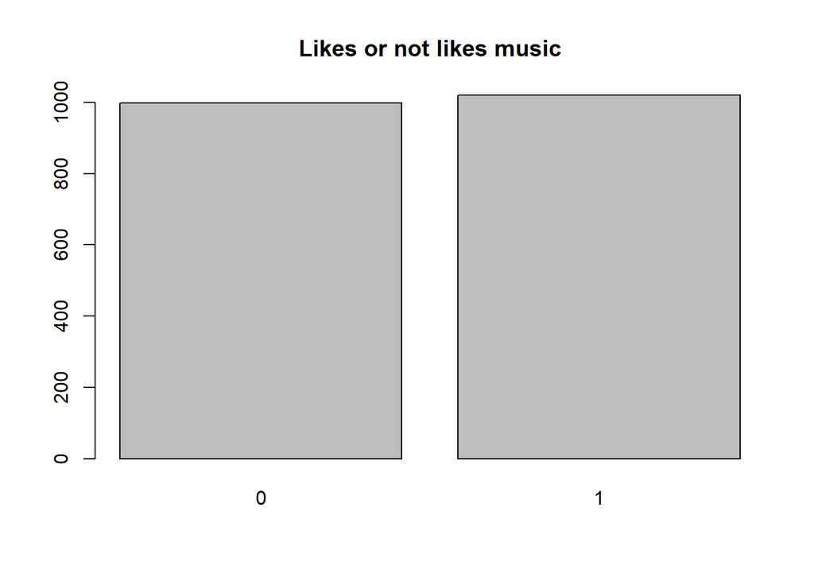

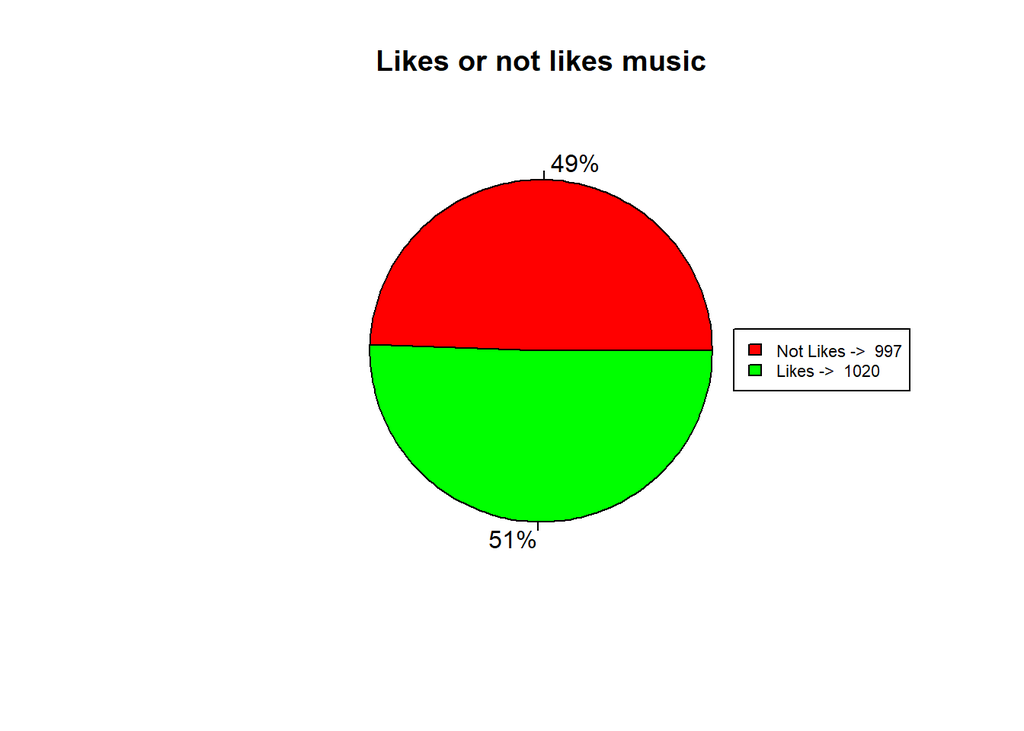

##### One of the advantage of this dataset is almost equal amount of negative and positive values of target

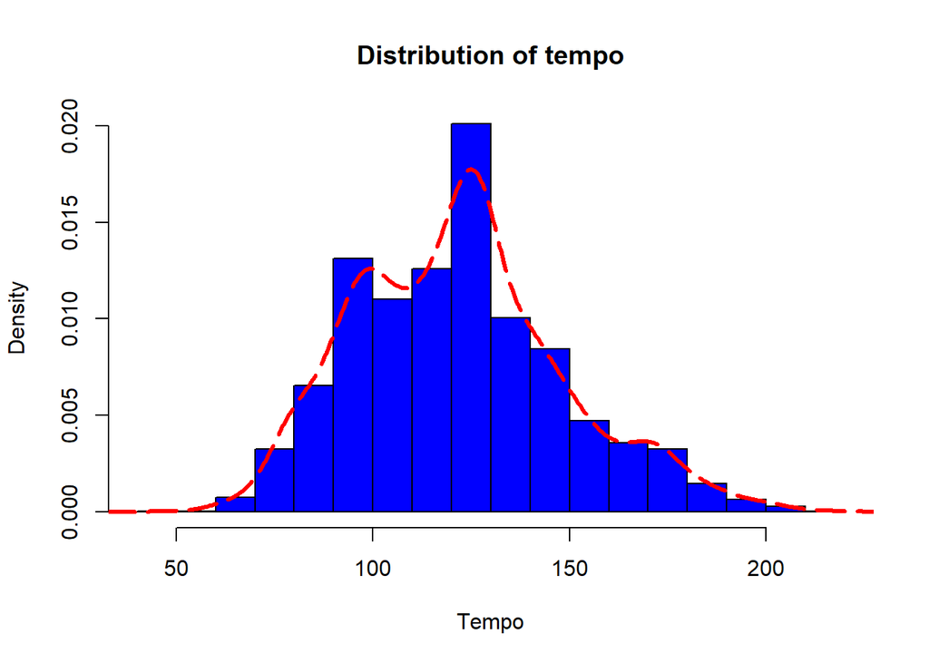

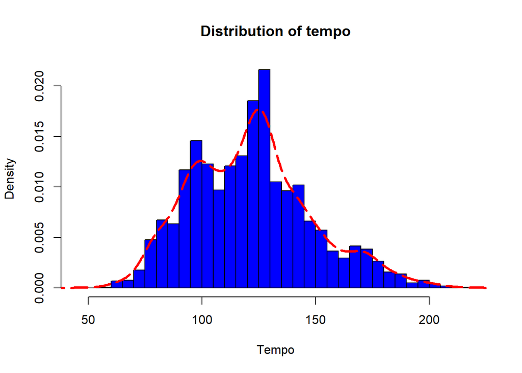

##### Here is shown that smaller range of tempo will be from 125 to 130

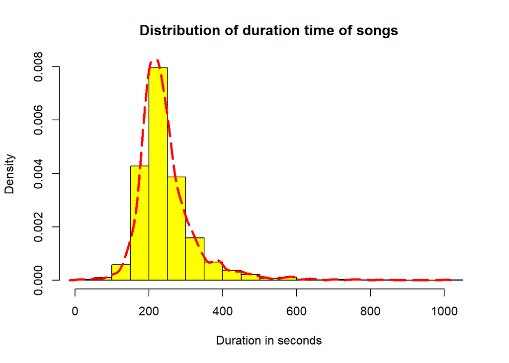

##### In above chart is shown the advantage of duration in rnage from 200 to 250 seconds

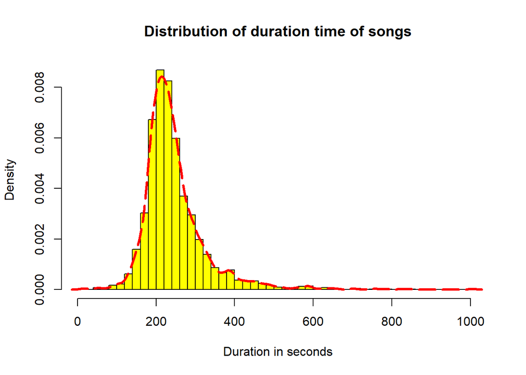

##### Here is shown that the most of songs have 220 +- 20 seconds

#### In below diagrams are shown the influences of the most relevant variables for target with easily distinct differences

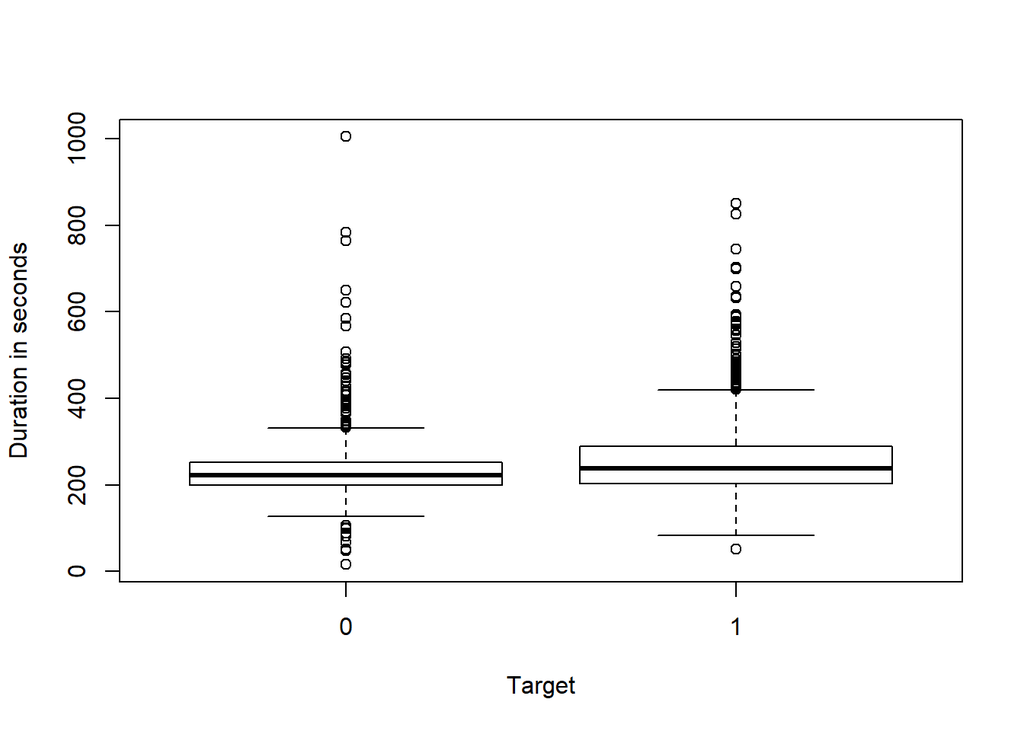

##### In above chart it is possible to notice little bigger mean values and median value for duration in seconds for target equal one

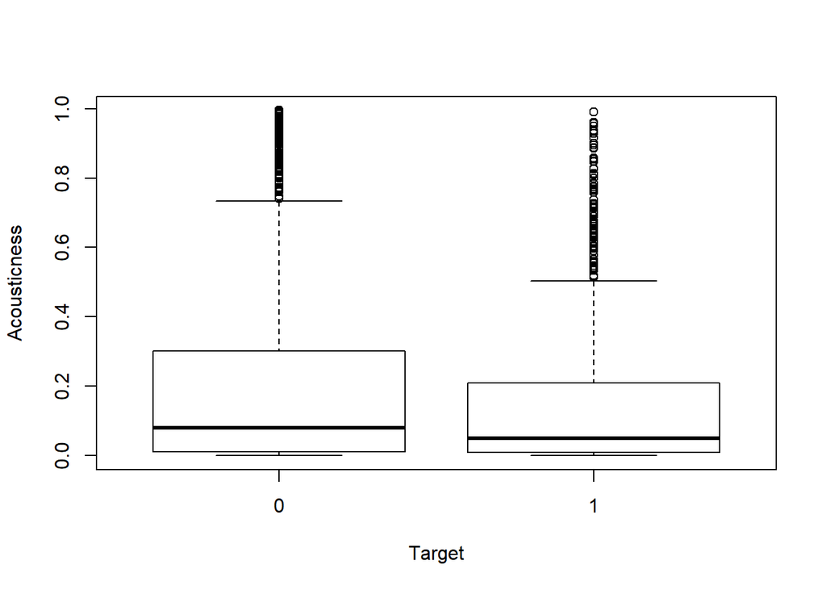

##### In above chart it is possible to notice little bigger mean values and median value for acousticness for target equal zero.

##### According of that it is likely to notice that user not enjoy with large values of acousticness

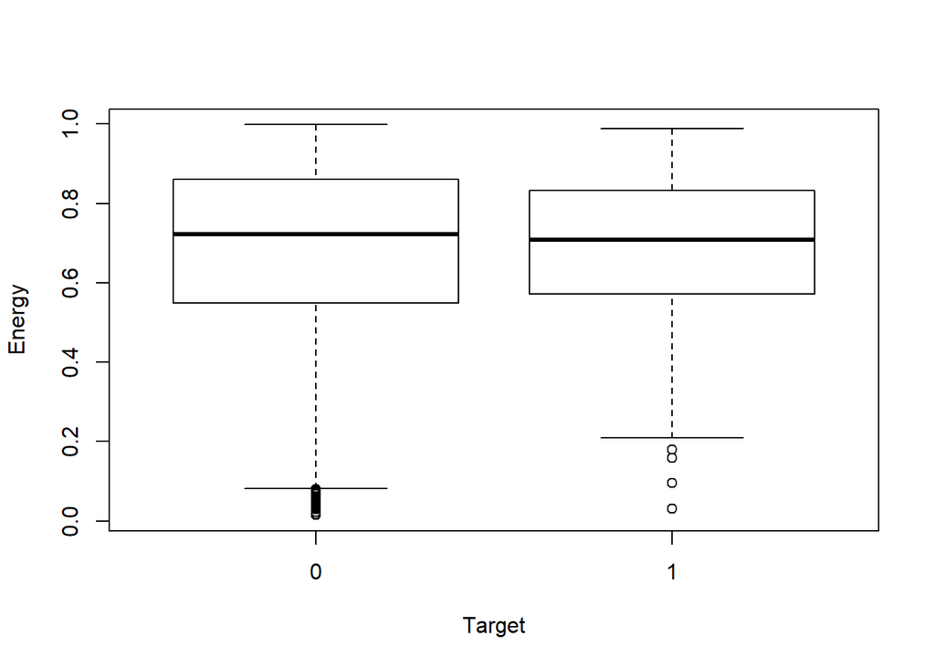

##### In above chart it is possible to notice little bigger mean values and median value for energy for target equal zero.

##### According of that it is likely to notice that user not enjoy with large values of energy

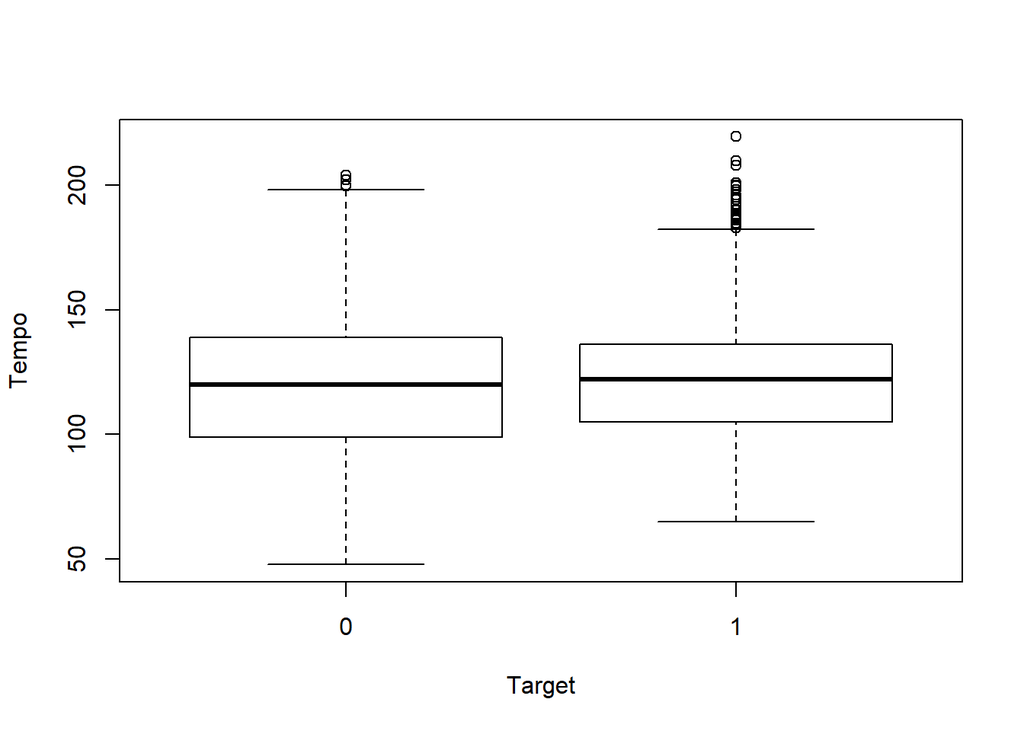

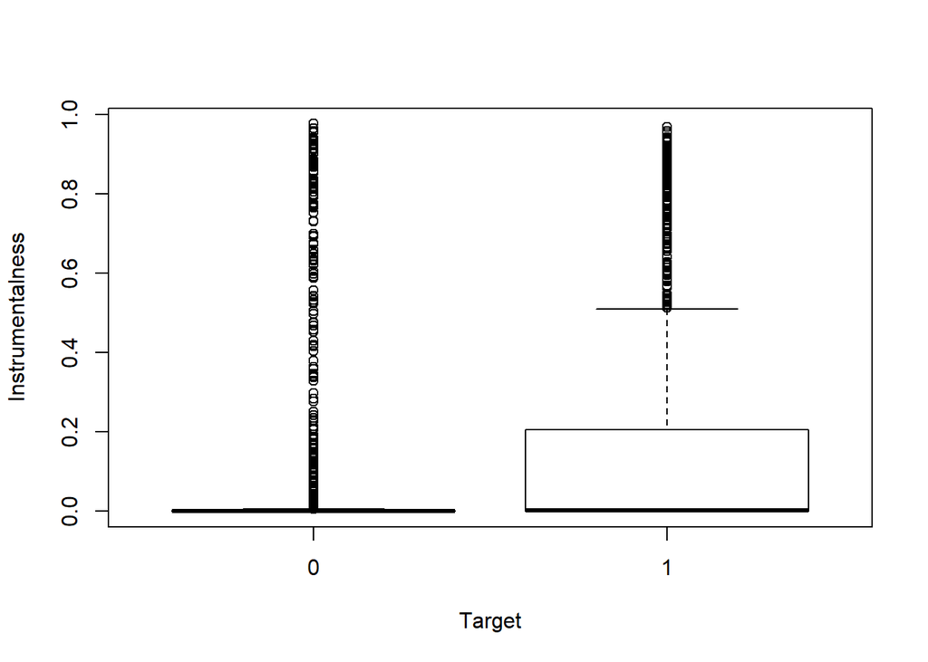

##### In above chart it is possible to notice much bigger mean values for instrumentalness for target equal one.

##### According of that it is likely to notice that user really enjoy of instrumentalness

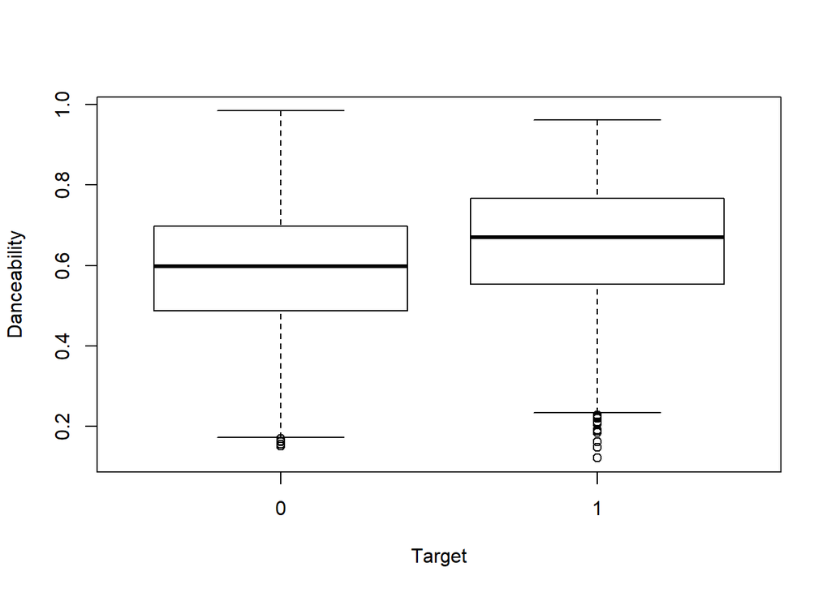

##### In above chart it is possible to notice much bigger mean values and median value for danceability for target equal one. ##### According of that it is likely to notice that user really enjoy with danceability songs

#### In below diagram is shown the influence between 2 variables

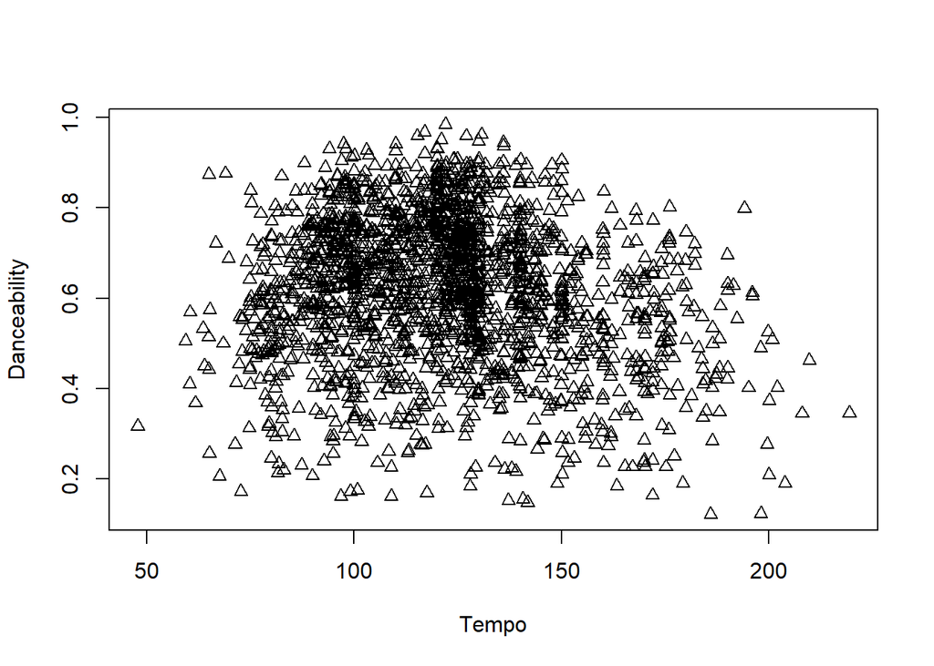

##### In above chart it is possible to notice that the best songs to dance are with tempo equal more or less 130

### Classification and predictions of targets

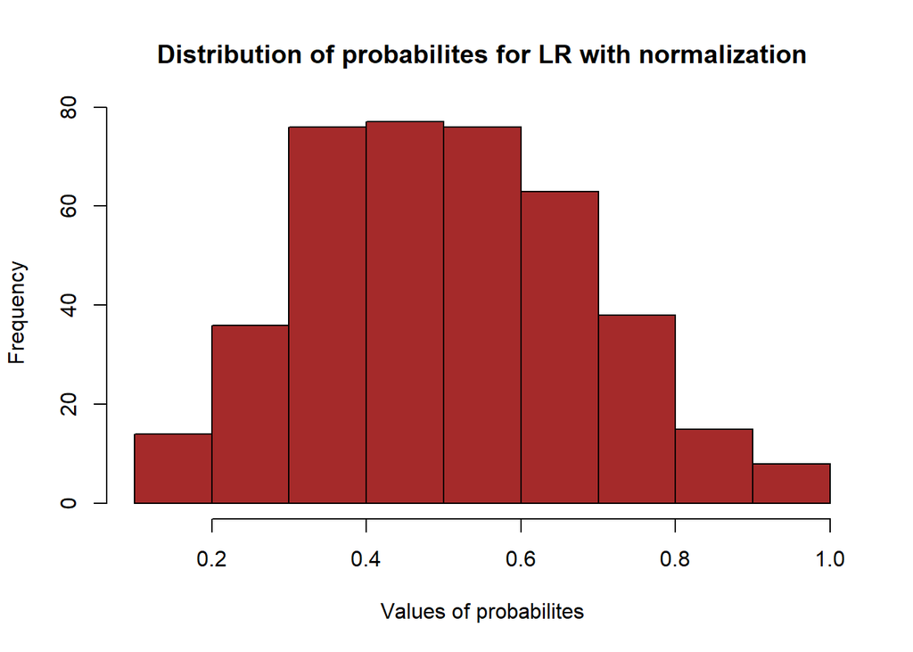

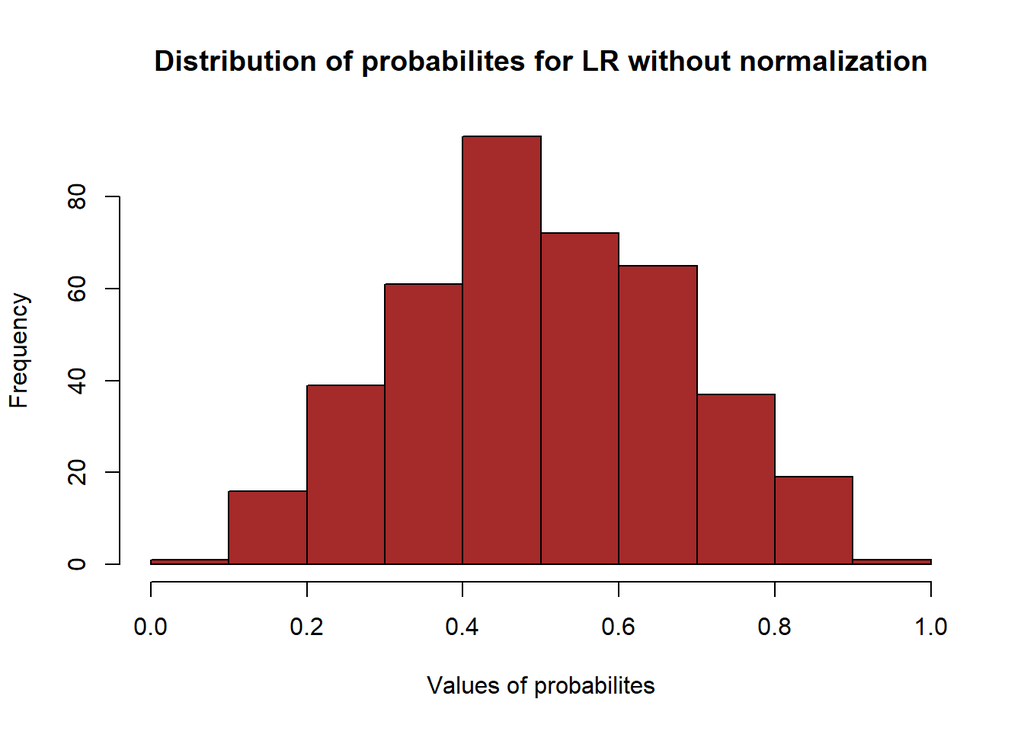

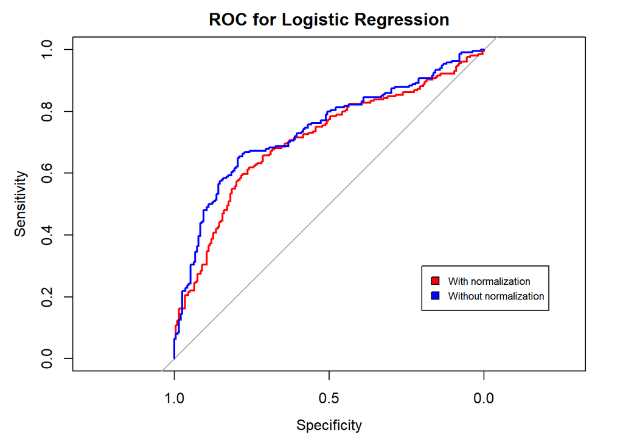

```
## F1 score for Logistic Regression with normalization ->  0.6782178
```

```
## F1 score for Logistic Regression without normalization ->  0.7058824
```

#### Trees with normalization

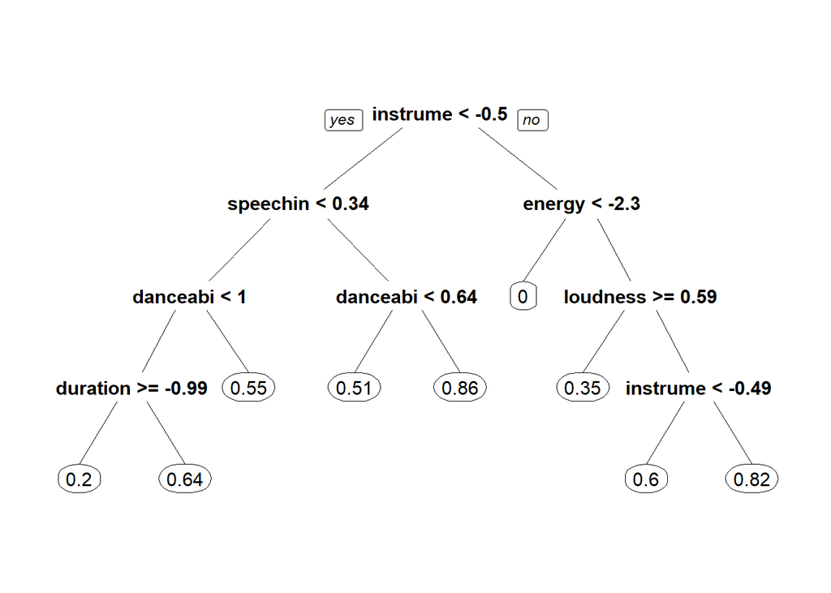

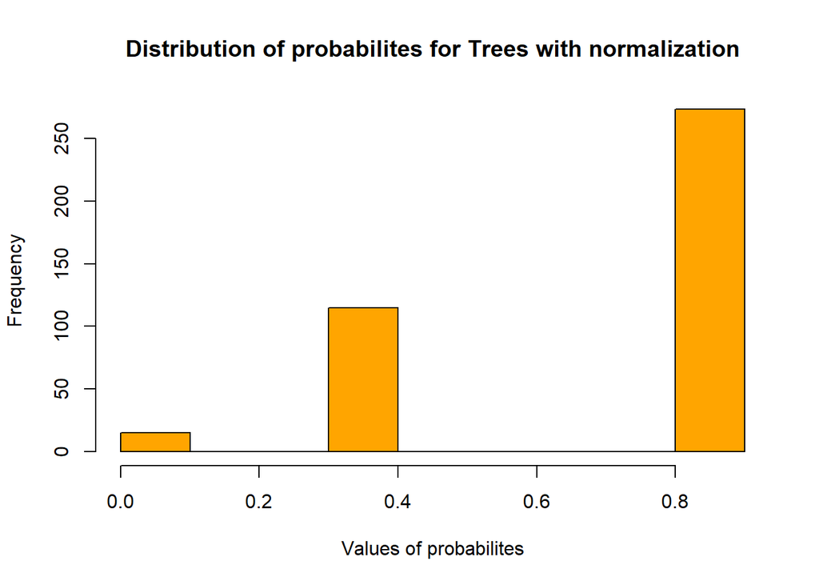

#### Trees without normalization

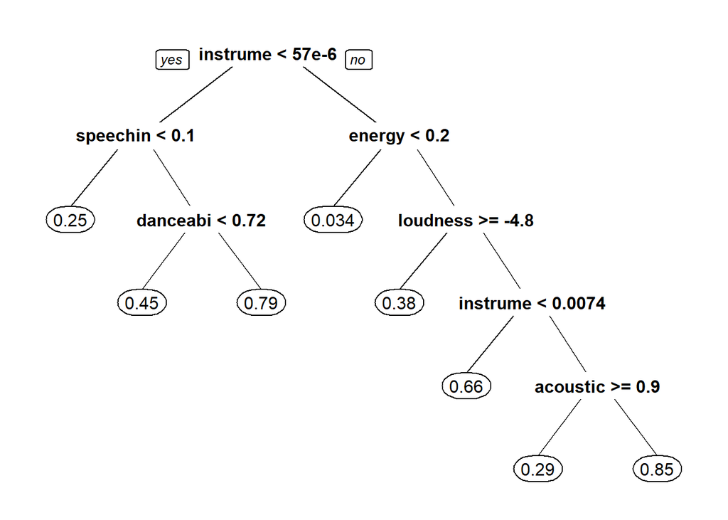

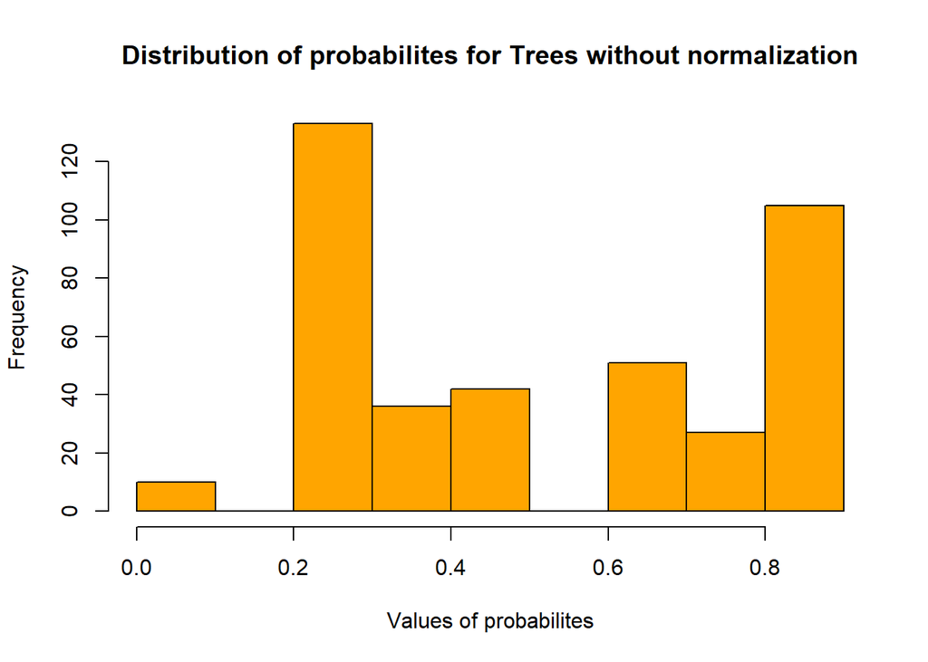

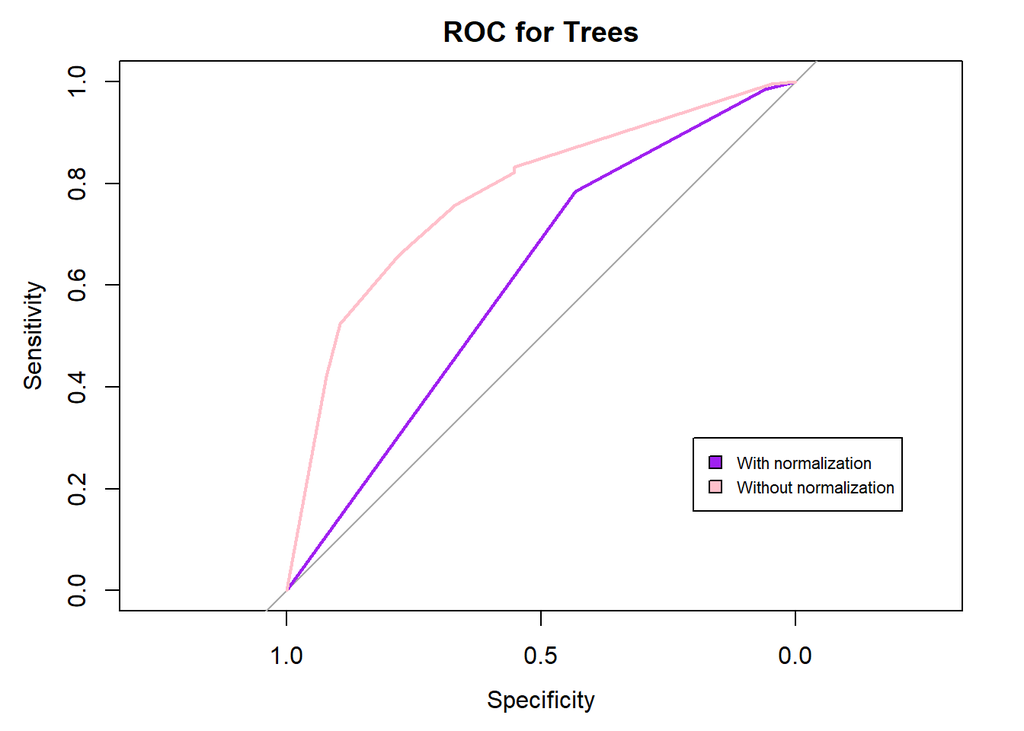

```
## F1 score for Trees with normalization ->  0.6708595
```

```
## F1 score for Trees without normalization ->  0.7103275
```

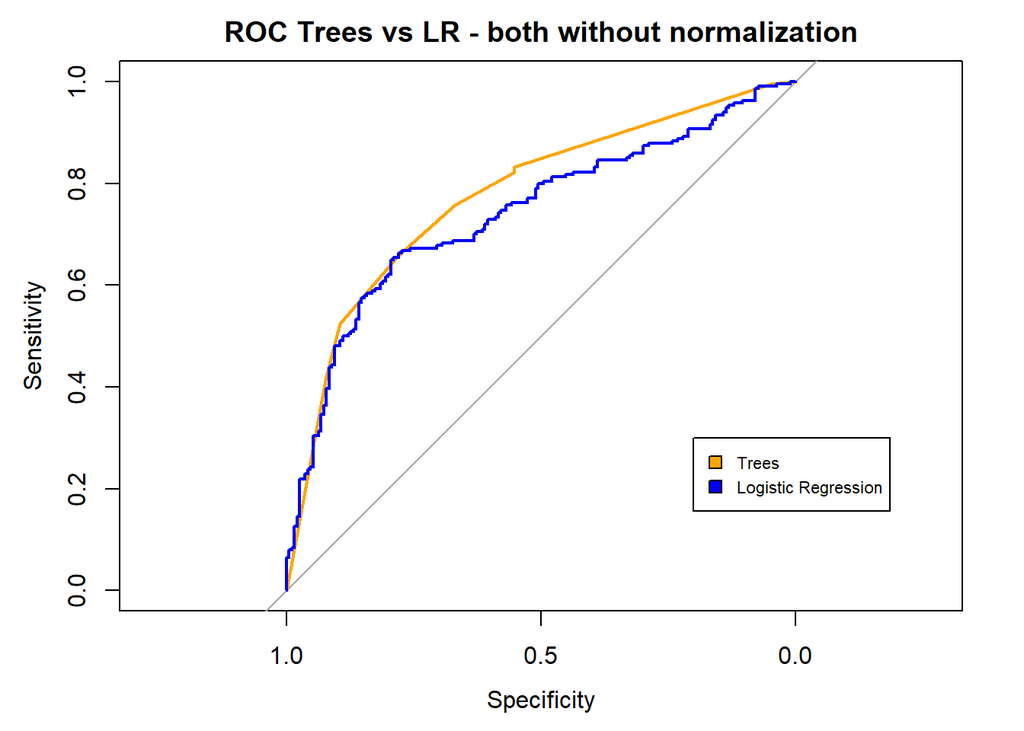

### Classification and predictions with hyperparameters tunning

##### It might be done with random tuning of hyperparameters (random values and searching hiperparameters spaces, but for visualizing purposes it is done with Cross-validation and manual(Grid Search) of hyperparameters - it is using a sequence of specific parameters with proper range. It might be called ‘hyperparameters space’)

#### Support Vector Machine - Support Vector Classifier (SVM - SVC)

##### It is used with ‘polynomial’ kernel

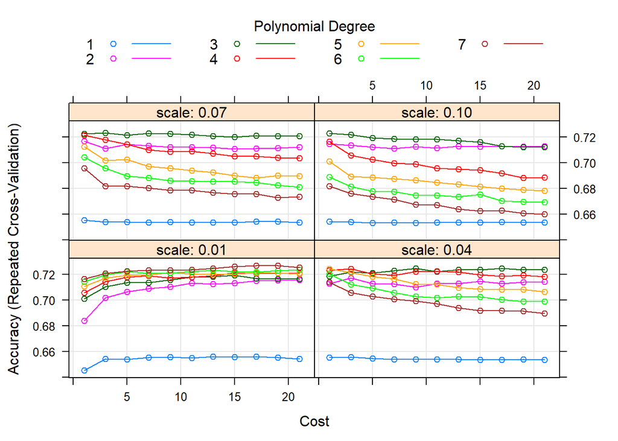

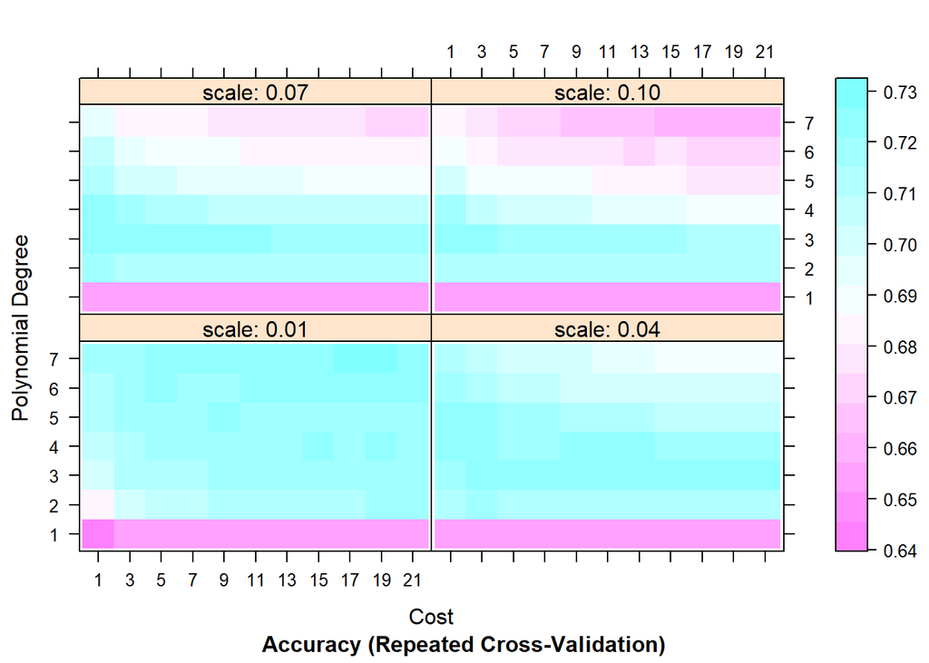

##### As we can notice on above charts that too large and too small amount of degree can give not satisfying results

#### eXtreme Gradient Boosting (XGB, xgboost)

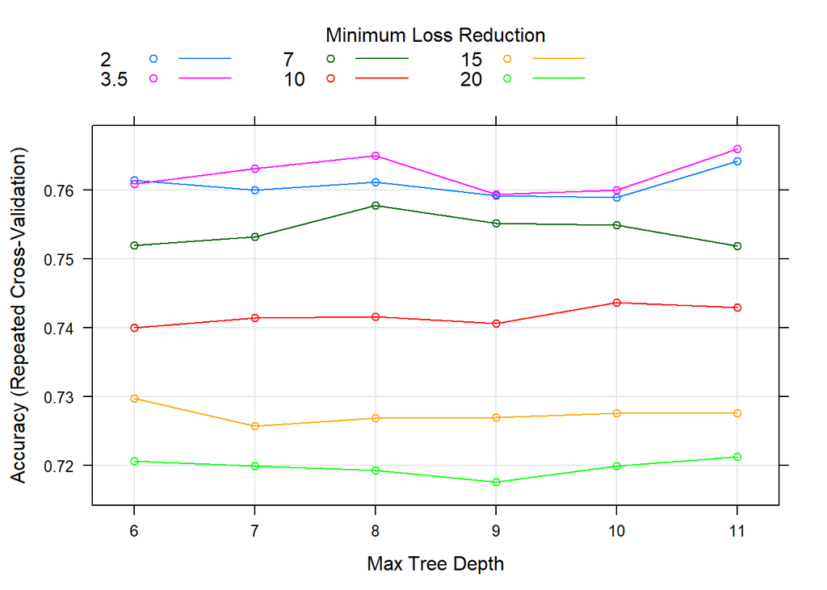

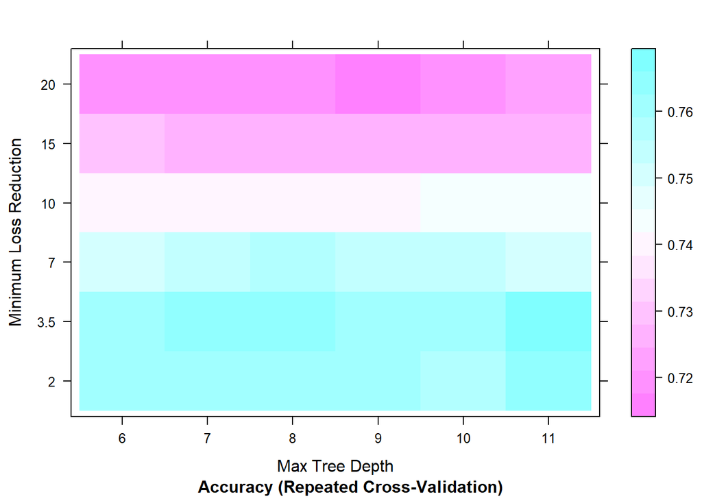

##### Also it is obvious to observe that the small values of Minimum Loss Reduction are giving most satisfying results from considering range

#### Gradient Boosting Machines (GBM)

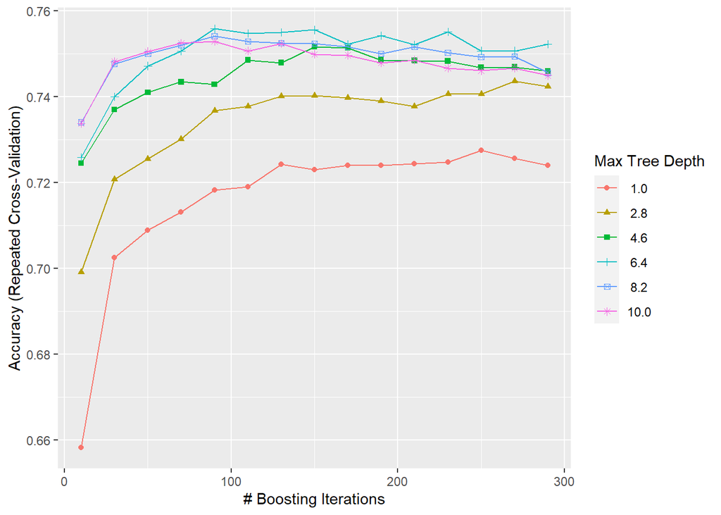

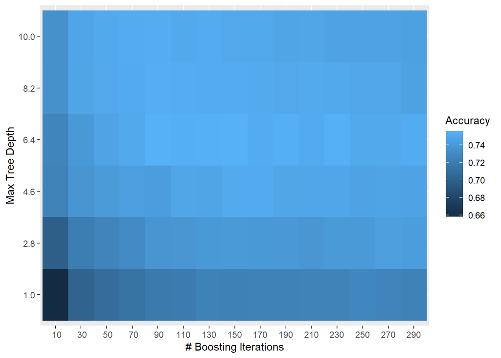

#### Random Forest

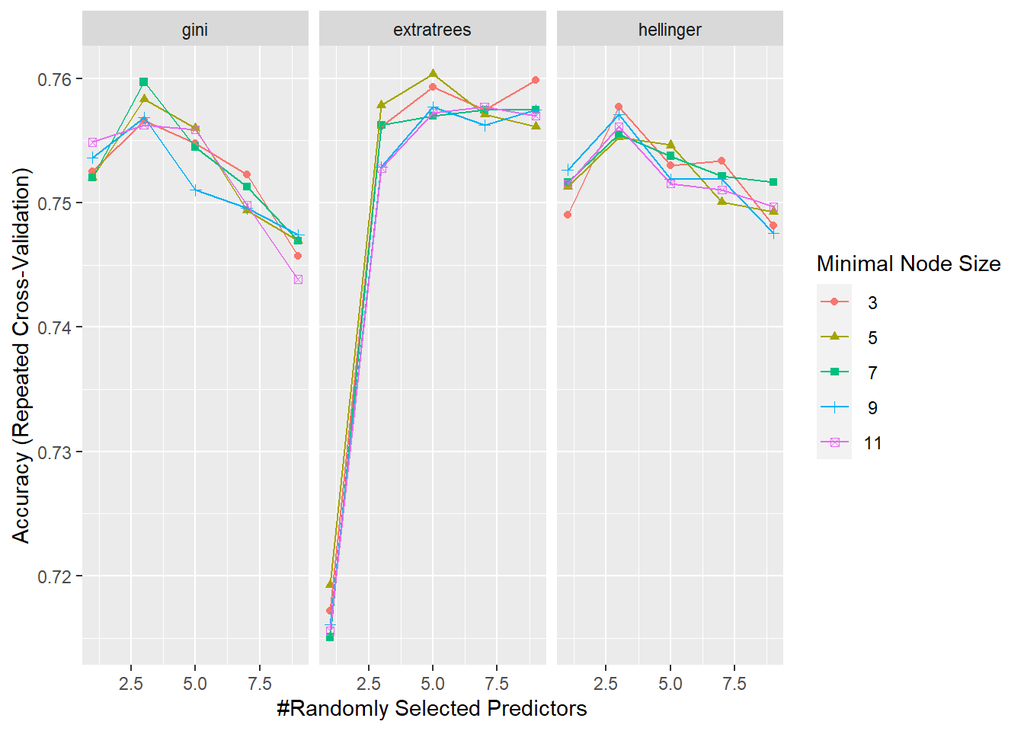

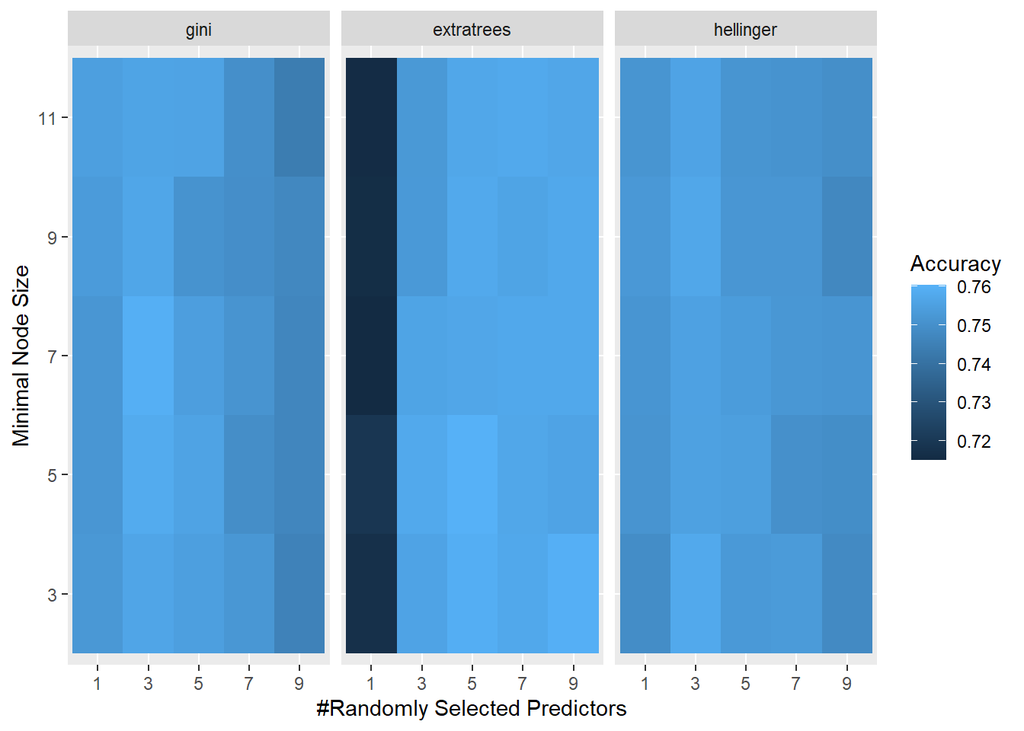

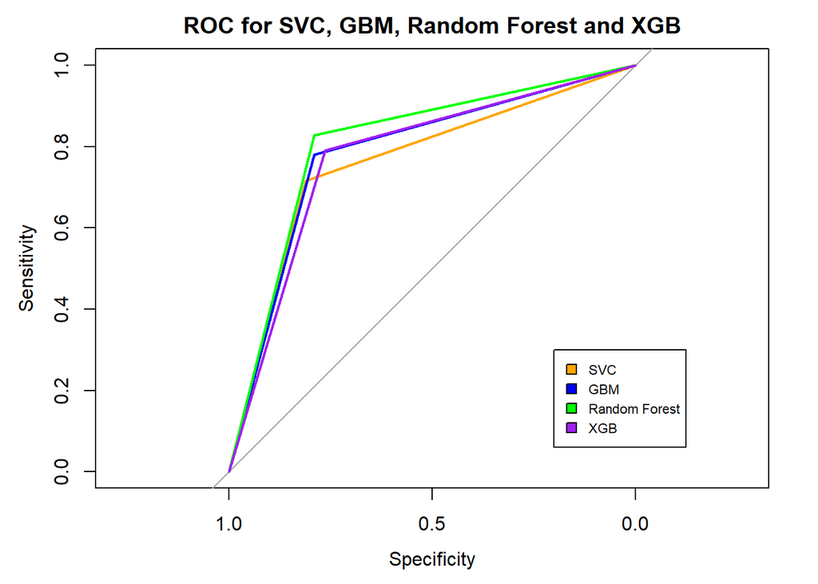

```
## F1 score for SVC ->  0.7593052
```

```
## F1 score for GBM ->  0.7933492
```

```
## F1 score for Random Forest ->  0.8213457
```

```
## F1 score for XGB ->  0.7897196
```

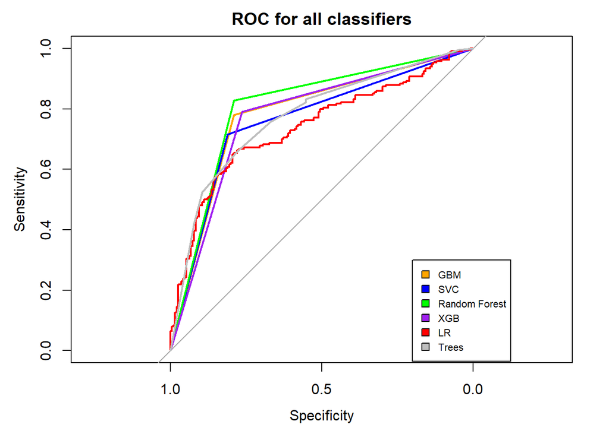